# classifier

## 5-fold CV logistic regression

```
variance of dispersion residuals not estimated (necessary only for differential expression calling)
```

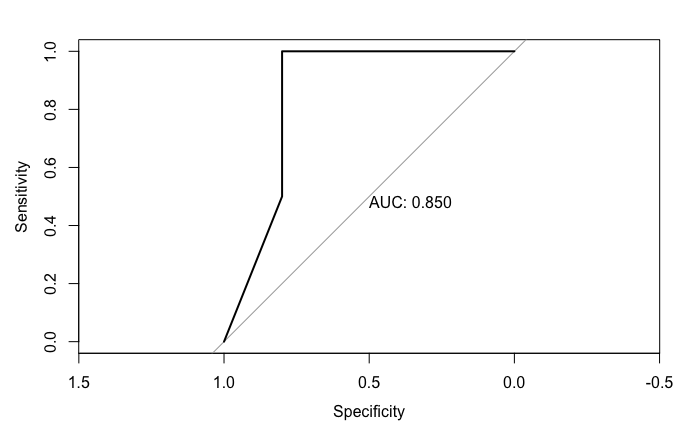

```
[1] "Model 1: Fold 1 AUC: 0.850"
[1] "Model 2: Fold 1 AUC: 0.975"
```

```
variance of dispersion residuals not estimated (necessary only for differential expression calling)
```

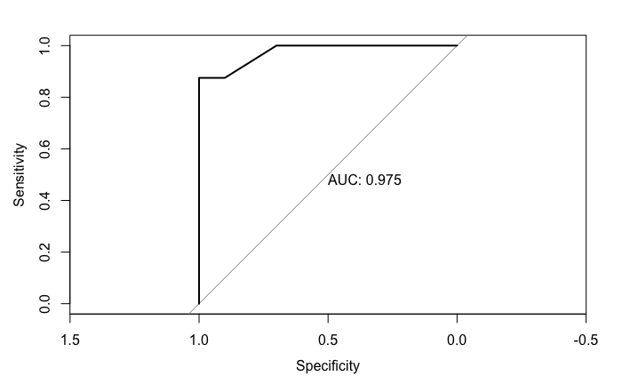

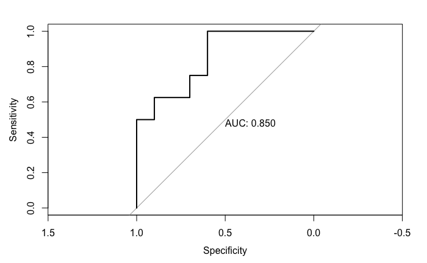

```
[1] "Model 1: Fold 2 AUC: 0.850"
[1] "Model 2: Fold 2 AUC: 1.000"
```

```
variance of dispersion residuals not estimated (necessary only for differential expression calling)
```

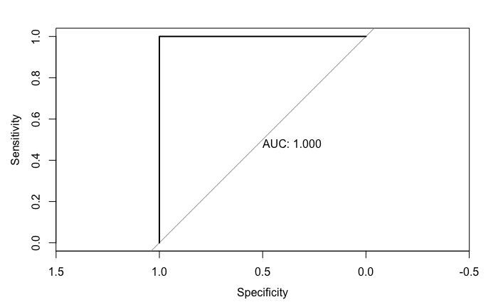

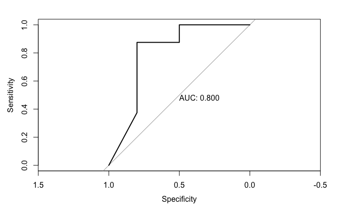

```
[1] "Model 1: Fold 3 AUC: 0.800"
[1] "Model 2: Fold 3 AUC: 0.900"
```

```
variance of dispersion residuals not estimated (necessary only for differential expression calling)
```

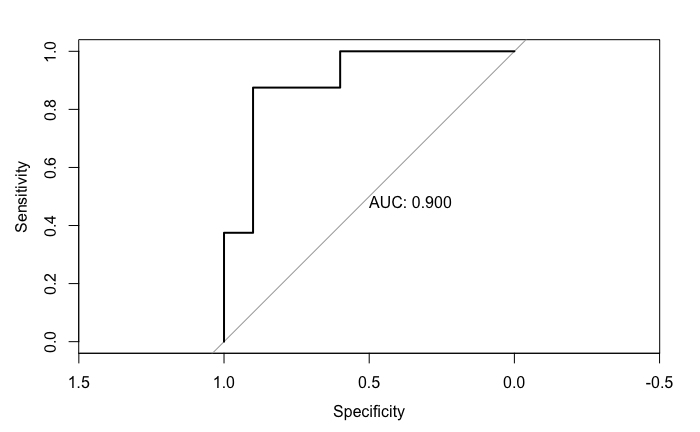

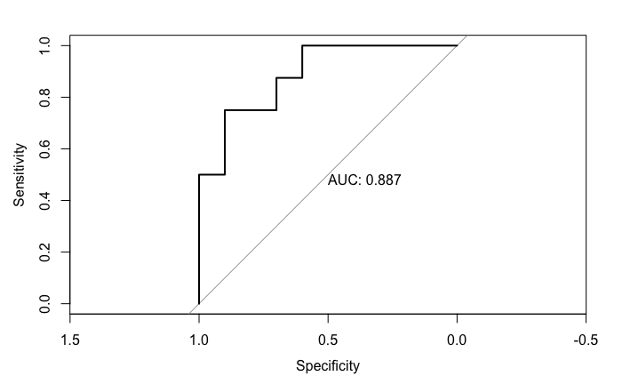

```
[1] "Model 1: Fold 4 AUC: 0.887"
[1] "Model 2: Fold 4 AUC: 0.863"
```

```
variance of dispersion residuals not estimated (necessary only for differential expression calling)
```

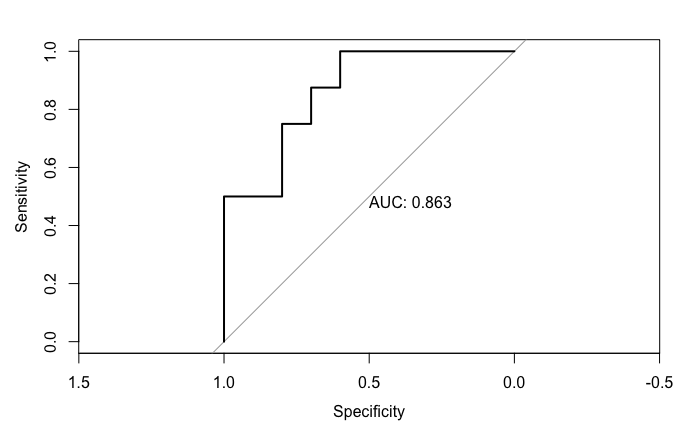

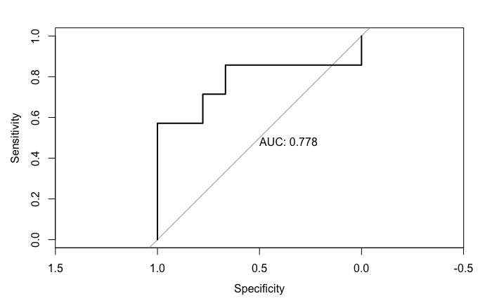

```
[1] "Model 1: Fold 5 AUC: 0.778"
[1] "Model 2: Fold 5 AUC: 0.873"
```

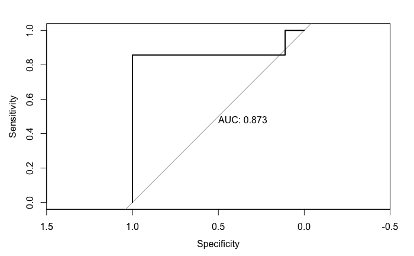

```r
# Get ensembl ID of FABP4
gene.id <- rownames(gene.symbol %>% subset(gene_symbol=="FABP4"))

# For storing pROC::roc results
mod1.fold.roc.adult <- list() # FABP4 only
mod2.fold.roc.adult <- list() # FABP4 + Versa

# For storing vst level of FABP4
cv.folds$FABP4.vst <- NA
# For storing predicted probability from the 2 classifiers
cv.folds$mod1.prob <- NA
cv.folds$mod2.prob <- NA

# For storing cutoff value, sensitivity and specificity at the Youden's index
mod1.youden <- list()
mod2.youden <- list()

# Iterate through 5 folds
for (k in c(1:5)) {
  test.fold <- cv.folds[cv.folds$fold==k,]
  train.folds <- cv.folds[cv.folds$fold!=k,]

  # Train data
  counts.train <- counts.adult[,train.folds$patient_id]
  keep.train <- rowSums(counts.train>=10) >= (0.2*ncol(counts.train))
  dds.train <- DESeqDataSetFromMatrix(
    countData = counts.train[keep.train,],
    colData = train.folds,
    design = ~1)
  dds.train <- estimateSizeFactors(dds.train)
  dds.train <- estimateDispersions(dds.train)
  vsd.train <- varianceStabilizingTransformation(dds.train) %>%
    assay %>%
    round(., digits=2)
  # Add FABP4 expression
  train.folds$FABP4 <- vsd.train[gene.id,]

  # Fit logistic regression: FABP4 only
  mod1.fit <- glm(
    LRTI ~ FABP4,
    data=train.folds,
    family="binomial")

  # Fit logistic regression: FABP4 & GPT-4
  mod2.fit <- glm(
    LRTI ~ FABP4 + Versa.LRTI.score,
    data=train.folds,
    family="binomial")

  # Test data
  counts.test <- counts.adult[,test.fold$patient_id]
  dds.test <- DESeqDataSetFromMatrix(
    countData = counts.test[keep.train,],
    colData = test.fold,
    design = ~1)
  dds.test <- estimateSizeFactors(dds.test)
  dispersionFunction(dds.test) <- dispersionFunction(dds.train) # assign the dispersion function from the training data directly
  vsd.test <- varianceStabilizingTransformation(dds.test, blind=FALSE) %>%
    assay %>%
    round(., digits=2)
  # Add FABP4 expression
  test.fold$FABP4 <- vsd.test[gene.id,]

  # Calculate logistic regression's probability
  test.fold$mod1.prob <- predict(
    mod1.fit, newdata=test.fold, type="response")
  test.fold$mod2.prob <- predict(
    mod2.fit, newdata=test.fold, type="response")

  # Store vst level of FABP4
  cv.folds[match(colnames(vsd.test),cv.folds$patient_id),"FABP4.vst"] <- vsd.test[gene.id,]
  # Store probability
  cv.folds[match(test.fold$patient_id,cv.folds$patient_id),"mod1.prob"] <- test.fold$mod1.prob
  cv.folds[match(test.fold$patient_id,cv.folds$patient_id),"mod2.prob"] <- test.fold$mod2.prob

  # Calculate ROC curve
  mod1.fold.roc.adult[[k]] <- pROC::roc(
    test.fold$LRTI ~ test.fold$mod1.prob,
    levels=c("0","1"),
    direction="<",
    plot=TRUE, print.auc=TRUE)
  mod2.fold.roc.adult[[k]] <- pROC::roc(
    test.fold$LRTI ~ test.fold$mod2.prob,
    levels=c("0","1"),
    direction="<",
    plot=TRUE, print.auc=TRUE)
  print(sprintf(
    "Model 1: Fold %d AUC: %.3f", k, mod1.fold.roc.adult[[k]]$auc))
  print(sprintf(
    "Model 2: Fold %d AUC: %.3f", k, mod2.fold.roc.adult[[k]]$auc))

  # Youden's index
  mod1.youden[[k]] <- pROC::coords(
    mod1.fold.roc.adult[[k]],
    x="best", best.method="youden",
    ret=c("threshold","sensitivity","specificity","accuracy")
  )
  mod2.youden[[k]] <- pROC::coords(
    mod2.fold.roc.adult[[k]],
    x="best", best.method="youden",
    ret=c("threshold","sensitivity","specificity","accuracy")
  )
}
```

Calculate the mean and s.d. of the AUCs.

```r
# Get the list of AUCs
mod1.fold.auc.adult <- unlist(lapply(
  mod1.fold.roc.adult,
  FUN=function(x) x$auc))
mod2.fold.auc.adult <- unlist(lapply(
  mod2.fold.roc.adult,
  FUN=function(x) x$auc))

# Model 1
# Mean
print(mean(mod1.fold.auc.adult))
```

```
[1] 0.8330556
```

```r
# SD
print(sd(mod1.fold.auc.adult))
```

```
[1] 0.04383699
```

```r
# Model 2
# Mean
print(mean(mod2.fold.auc.adult))
```

```
[1] 0.9221032
```

```r
# SD
print(sd(mod2.fold.auc.adult))
```

```
[1] 0.06188021
```

Export

```r
write.csv(
  cv.folds,
  "output/classifier_5fold_CV.csv",
  row.names=FALSE
)
```

## Mean ROC curve

Interpolate the ROC to calculate the mean AUC, taking inspiration from https://stats.stackexchange.com/a/187003

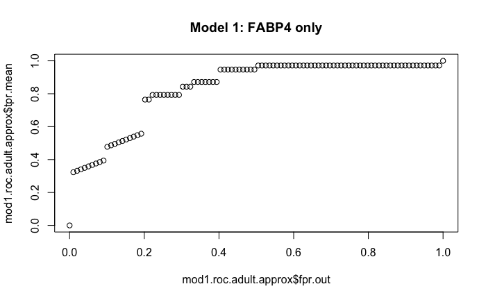

```r
# Initialize data frame for storing interpolated TPR and FPR
mod1.roc.adult.approx <- data.frame(
  fpr.out=seq(0, 1, length.out=100),
  tpr1=0,
  tpr2=0,
  tpr3=0,
  tpr4=0,
  tpr5=0)
mod2.roc.adult.approx <- mod1.roc.adult.approx
for (k in 1:5) {
  # Model 1
  fpr <- rev(1-mod1.fold.roc.adult[[k]]$specificities)
  tpr <- rev(mod1.fold.roc.adult[[k]]$sensitivities)
  tpr.out <- approx(fpr, tpr,
                    xout=mod1.roc.adult.approx$fpr.out,
                    method="linear", ties="ordered")
  mod1.roc.adult.approx[,k+1] <- tpr.out$y

  # Model 2
  fpr <- rev(1-mod2.fold.roc.adult[[k]]$specificities)
  tpr <- rev(mod2.fold.roc.adult[[k]]$sensitivities)
  tpr.out <- approx(fpr, tpr,
                    xout=mod2.roc.adult.approx$fpr.out,
                    method="linear", ties="ordered")
  mod2.roc.adult.approx[,k+1] <- tpr.out$y
}

# Average TPR and FPR
mod1.roc.adult.approx$tpr.mean <- rowMeans(mod1.roc.adult.approx[,2:6])
mod1.roc.adult.approx$tpr.sd <- apply(
  mod1.roc.adult.approx[,2:6],
  MARGIN=1, FUN=sd
)

mod1.roc.adult.approx[1,"tpr.mean"] <- 0 # Force the mean ROC to start at (0,0)
plot(mod1.roc.adult.approx$fpr.out, mod1.roc.adult.approx$tpr.mean,
     main="Model 1: FABP4 only")
```

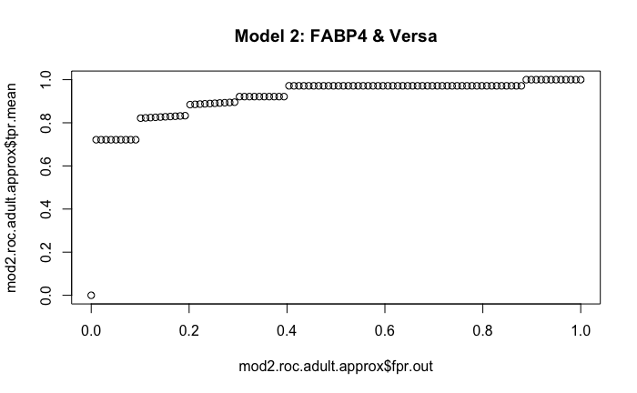

```r
mod2.roc.adult.approx$tpr.mean <- rowMeans(mod2.roc.adult.approx[,2:6])
mod2.roc.adult.approx$tpr.sd <- apply(
  mod2.roc.adult.approx[,2:6],
  MARGIN=1, FUN=sd
)
mod2.roc.adult.approx[1,"tpr.mean"] <- 0 # Force the mean ROC to start at (0,0)
plot(mod2.roc.adult.approx$fpr.out, mod2.roc.adult.approx$tpr.mean,
     main="Model 2: FABP4 & Versa")
```

Plot interpolated ROCs

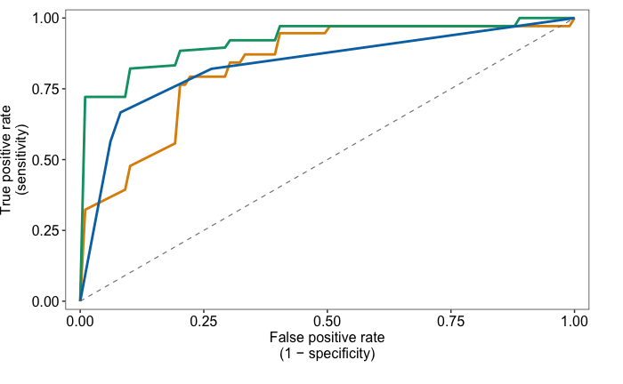

```r
p <- ggplot()

# Model 1
p <- p + geom_line(
  data=mod1.roc.adult.approx,
  aes(x=fpr.out, y=tpr.mean),
  col=color.fabp4, linewidth=1)

# Model 2
p <- p + geom_line(
  data=mod2.roc.adult.approx,
  aes(x=fpr.out, y=tpr.mean),
  col=color.integrated, linewidth=1)

# GPT-4
p <- p + geom_line(
  data=data.frame(
      x=rev(1-gpt4$specificities),
      y=rev(gpt4$sensitivities)),
  aes(x=x, y=y),
  col=color.gpt4, linewidth=1
)

# Add the diagonal line
p <- p +
  geom_segment(
    aes(x=0,xend=1,y=0,yend=1),
    linetype="dashed", col="grey50", linewidth=0.4)

# Formatting
p <- p +
  labs(x="False positive rate\n(1 \u2212 specificity)",
       y="True positive rate\n(sensitivity)") +
  scale_x_continuous(limits=c(-0.03,1.03), expand=c(0,0)) +
  scale_y_continuous(limits=c(-0.03,1.03), expand=c(0,0)) +
  theme_bw() +
  theme(
    plot.title = element_text(hjust = 0.5, size=12, face="plain"),
    axis.text = element_text(size=12, color="black"),
    text = element_text(size=12, family="Arial"),
    panel.grid.major = element_blank(),
    panel.grid.minor = element_blank(),
    plot.margin = unit(c(0.3,1,0.7,0), "cm")
  )
p
ggsave(
  "output/both_mean_roc.svg",
  plot=p,
  width=3.55, height=3.57, units="in")
```

## Youden’s index

Calculate the mean and s.d. of sensitivity, specificity and accuracy at the Youden’s index.

```r
# Convert the youden list to dataframe
mod1.youden.df <- Reduce(rbind, mod1.youden)
rownames(mod1.youden.df) <- 1:5
mod2.youden.df <- Reduce(rbind, mod2.youden)
rownames(mod2.youden.df) <- 1:5

print(mod1.youden.df)
```

|  | threshold | sensitivity | specificity | accuracy |
| --- | --- | --- | --- | --- |
| 1 | 0.6536384 | 1.0000000 | 0.8 | 0.8888889 |
| 2 | 0.3182131 | 1.0000000 | 0.6 | 0.7777778 |
| 3 | 0.4978032 | 0.8750000 | 0.8 | 0.8333333 |
| 4 | 0.4685422 | 0.7500000 | 0.9 | 0.8333333 |
| 5 | 0.7776486 | 0.5714286 | 1.0 | 0.8125000 |

```r
print(mod2.youden.df)
```

|  | threshold | sensitivity | specificity | accuracy |
| --- | --- | --- | --- | --- |
| 1 | 0.65632609 | 0.8750000 | 1.0 | 0.9444444 |
| 2 | 0.42138781 | 1.0000000 | 1.0 | 1.0000000 |
| 3 | 0.71933006 | 0.8750000 | 0.9 | 0.8888889 |
| 4 | 0.03443587 | 1.0000000 | 0.6 | 0.7777778 |
| 5 | 0.48589399 | 0.8571429 | 1.0 | 0.9375000 |

```r
print("Sensitivity")
```

```
[1] "Sensitivity"
```

```r
# Model 1
# Mean
print(mean(mod1.youden.df$sensitivity))
```

```
[1] 0.8392857
```

```r
# SD
print(sd(mod1.youden.df$sensitivity))
```

```
[1] 0.1821078
```

```r
# Model 2
# Mean
print(mean(mod2.youden.df$sensitivity))
```

```
[1] 0.9214286
```

```r
# SD
print(sd(mod2.youden.df$sensitivity))
```

```
[1] 0.0720951
```

```r
print("Specificity")
```

```
[1] "Specificity"
```

```r
# Model 1
# Mean
print(mean(mod1.youden.df$specificity))
```

```
[1] 0.82
```

```r
# SD
print(sd(mod1.youden.df$specificity))
```

```
[1] 0.148324
```

```r
# Model 2
# Mean
print(mean(mod2.youden.df$specificity))
```

```
[1] 0.9
```

```r
# SD
print(sd(mod2.youden.df$specificity))
```

```
[1] 0.1732051
```

```r
print("Accuracy")
```

```
[1] "Accuracy"
```

```r
# Model 1
# Mean
print(mean(mod1.youden.df$accuracy))
```

```
[1] 0.8291667
```

```r
# SD
print(sd(mod1.youden.df$accuracy))
```

```
[1] 0.04037345
```

```r
# Model 2
# Mean
print(mean(mod2.youden.df$accuracy))
```

```
[1] 0.9097222
```

```r
# SD
print(sd(mod2.youden.df$accuracy))
```

```
[1] 0.08362218
```

# Compare all predictions to true diagnosis

## Classifiers

I will plot the confusion matrix to compare different predictions to true diagnosis

Compare FABP4 prediction to true diagnosis

```r
# Number of patients per predicted and true LRTI diagnosis
temp1 <- cv.folds %>%
  select(patient_id, LRTI, mod1.prob) %>%
  mutate(mod1.pred=as.factor(mod1.prob>=0.5)) %>%
  group_by(mod1.pred, LRTI) %>%
  summarise(count = n(), .groups = 'drop')
print(temp1)
```

| mod1.pred | LRTI | count |
| --- | --- | --- |
| FALSE | 0 | 38 |
| FALSE | 1 | 8 |
| TRUE | 0 | 11 |
| TRUE | 1 | 31 |

```r
# Calculate proportion
temp1 <- temp1 %>%
  group_by(mod1.pred) %>%
  mutate(prop=count/sum(count)) %>%
  ungroup()
print(temp1)
```

| mod1.pred | LRTI | count | prop |
| --- | --- | --- | --- |
| FALSE | 0 | 38 | 0.8260870 |
| FALSE | 1 | 8 | 0.1739130 |
| TRUE | 0 | 11 | 0.2619048 |
| TRUE | 1 | 31 | 0.7380952 |

Compare FABP4 + GPT-4 prediction to true diagnosis

```r
# Number of patients per predicted and true LRTI diagnosis
temp3 <- cv.folds %>%
  select(patient_id, LRTI, mod2.prob) %>%
  mutate(mod2.pred=as.factor(mod2.prob>=0.5)) %>%
  group_by(mod2.pred, LRTI) %>%
  summarise(count = n(), .groups = 'drop')
print(temp3)
```

| mod2.pred | LRTI | count |
| --- | --- | --- |
| FALSE | 0 | 43 |
| FALSE | 1 | 6 |
| TRUE | 0 | 6 |
| TRUE | 1 | 33 |

```r
# Calculate proportion
temp3 <- temp3 %>%
  group_by(mod2.pred) %>%
  mutate(prop=count/sum(count)) %>%
  ungroup()
print(temp3)
```

| mod2.pred | LRTI | count | prop |
| --- | --- | --- | --- |
| FALSE | 0 | 43 | 0.8775510 |
| FALSE | 1 | 6 | 0.1224490 |
| TRUE | 0 | 6 | 0.1538462 |
| TRUE | 1 | 33 | 0.8461538 |

Plot confusion matrices of FABP4 and integrated classifiers

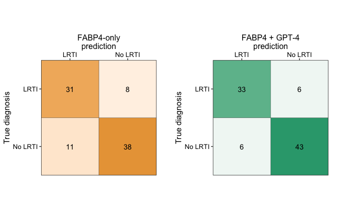

```r
p.fabp4 <- ggplot(
  data=temp1,
  aes(x=mod1.pred, y=LRTI)) +
  geom_tile(aes(fill=count), color="black") +
  geom_text(aes(label=count), vjust = 0.5) +
  labs(x="FABP4-only\nprediction",
       y="True diagnosis") +
  scale_fill_gradient(
    low="white", high=color.fabp4,
    limits=c(3,46), guide="none") +
  scale_x_discrete(
    expand=c(0,0), limits=c("TRUE","FALSE"),
    labels=c("LRTI","No LRTI"), position="top") +
  scale_y_discrete(expand=c(0,0), labels=c("No LRTI","LRTI")) +
  coord_fixed(ratio=1) +
  theme_bw() + my.theme.cm
p.integrated <- ggplot(
  data=temp3,
  aes(x=mod2.pred, y=LRTI)) +
  geom_tile(aes(fill=count), color="black") +
  geom_text(aes(label=count), vjust = 0.5) +
  labs(x="FABP4 + GPT-4\nprediction",
       y="True diagnosis") +
  scale_fill_gradient(
    low="white", high=color.integrated,
    limits=c(3,46), guide="none") +
  scale_x_discrete(
    expand=c(0,0), limits=c("TRUE","FALSE"),
    labels=c("LRTI","No LRTI"), position="top") +
  scale_y_discrete(expand=c(0,0), labels=c("No LRTI","LRTI")) +
  coord_fixed(ratio=1) +
  theme_bw() + my.theme.cm
p.fabp4 + p.integrated + plot_layout(nrow=1)
```

## Naive physicians

Compare naive physcians’ adjudication

```r
temp4 <- naive %>%
  select(patient_id, LRTI, naive_LRTI_score) %>%
  mutate(naive.pred=as.factor(naive_LRTI_score>=1)) %>%
  group_by(naive.pred, LRTI) %>%
  summarise(count = n(), .groups = 'drop')
print(temp4)
```

| naive.pred | LRTI | count |
| --- | --- | --- |
| FALSE | 0 | 43 |
| FALSE | 1 | 8 |
| TRUE | 0 | 6 |
| TRUE | 1 | 31 |

```r
# Calculate proportion
temp4 <- temp4 %>%
  group_by(naive.pred) %>%
  mutate(prop=count/sum(count)) %>%
  ungroup()
print(temp4)
```

| naive.pred | LRTI | count | prop |
| --- | --- | --- | --- |
| FALSE | 0 | 43 | 0.8431373 |
| FALSE | 1 | 8 | 0.1568627 |
| TRUE | 0 | 6 | 0.1621622 |
| TRUE | 1 | 31 | 0.8378378 |

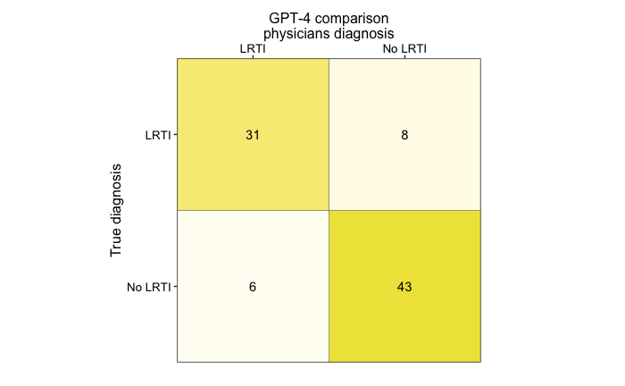

```r
p.naive <- ggplot(
  data=temp4,
  aes(x=naive.pred, y=LRTI)) +
  geom_tile(aes(fill=count), color="black") +
  geom_text(aes(label=count), vjust = 0.5) +
  labs(x="GPT-4 comparison\nphysicians diagnosis",
       y="True diagnosis") +
  scale_fill_gradient(
    low="white", high=color.naive,
    limits=c(3,46), guide="none") +
  scale_x_discrete(
    expand=c(0,0), limits=c("TRUE","FALSE"),
    labels=c("LRTI","No LRTI"), position="top") +
  scale_y_discrete(expand=c(0,0), labels=c("No LRTI","LRTI")) +
  coord_fixed(ratio=1) +
  theme_bw() + my.theme.cm
p.naive
```

## All comparisons

Export all confusion matrices

```r
ggsave(
  "output/all_confusion_matrix.svg",
  plot=p.initial + p.fabp4 + p.naive + p.gpt4 + p.integrated + plot_spacer() + plot_layout(nrow=2),
  width=8.5, height=4.7, units="in")
```

# Naive vs GPT-4 diagnosis

```r
temp5 <- naive %>%
  select(patient_id, Versa.LRTI.score, naive_LRTI_score) %>%
  group_by(Versa.LRTI.score, naive_LRTI_score) %>%
  summarise(count = n(), .groups = 'drop')
print(temp5)
```

| Versa.LRTI.score | naive_LRTI_score | count |
| --- | --- | --- |
| 0 | 0 | 39 |
| 0 | 1 | 4 |
| 1 | 0 | 9 |
| 1 | 1 | 2 |
| 1 | 2 | 2 |
| 1 | 3 | 2 |
| 2 | 0 | 1 |
| 2 | 2 | 1 |
| 2 | 3 | 3 |
| 3 | 0 | 2 |

[output cut: 3 more lines]

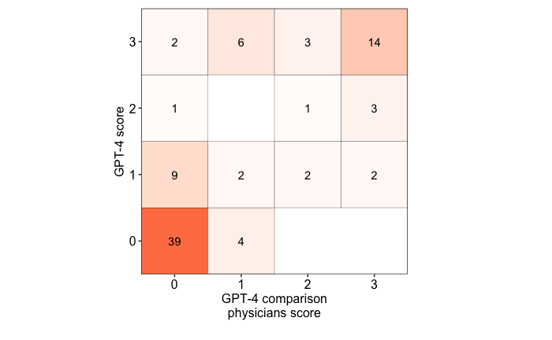

```r
p.gpt4.naive <- ggplot(
  data=temp5,
  aes(x=as.factor(naive_LRTI_score),
      y=as.factor(Versa.LRTI.score))) +
  geom_tile(aes(fill=count), color="black") +
  geom_text(aes(label=count), vjust = 0.5) +
  labs(x="GPT-4 comparison\nphysicians score",
       y="GPT-4 score") +
  scale_fill_gradient(
    low="white", high="coral",
    limits=c(0,39),
    na.value="white", guide="none") +
  scale_x_discrete(expand=c(0,0)) +
  scale_y_discrete(expand=c(0,0)) +
  coord_fixed(ratio=1) +
  theme_bw() + my.theme
p.gpt4.naive
ggsave(
  "output/gpt4-vs-naive.svg",
  plot=p.gpt4.naive,
  width=2.7, height=2.7, units="in")
```